# Step 3: Transforming Data

### Left Join

A left join returns all rows from the left data frame (the first data frame specified) and matching rows from the right data frame (the second data frame specified). Non-matching rows in the right data frame have NULL (or NA) values in the result.

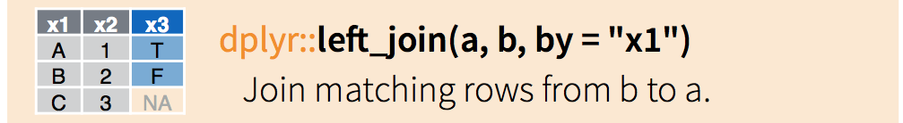

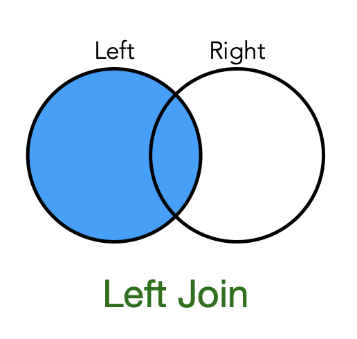

```r
left
```

| key1 | A | B |
| --- | --- | --- |
| K0 | A0 | B0 |
| K1 | A1 | B1 |
| K2 | A2 | B2 |
| K3 | A3 | B3 |

```r
right
```

| key1 | C | D |
| --- | --- | --- |
| K0 | C0 | D0 |
| K1 | C1 | D1 |
| K1 | C2 | D2 |
| K4 | C3 | D3 |

```r
left_join(left, right, by = "key1")
```

| key1 | A | B | C | D |
| --- | --- | --- | --- | --- |
| K0 | A0 | B0 | C0 | D0 |
| K1 | A1 | B1 | C1 | D1 |
| K1 | A1 | B1 | C2 | D2 |
| K2 | A2 | B2 | NA | NA |
| K3 | A3 | B3 | NA | NA |

### Right join

A right join is similar to a left join but returns all rows from the right data frame and matching rows from the left data frame. Non-matching rows in the left data frame have NULL (or NA) values in the result.

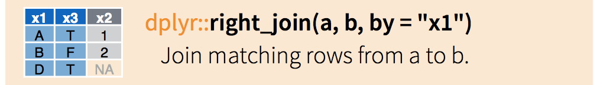

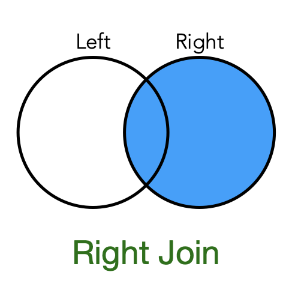

```r
left
```

| key1 | A | B |
| --- | --- | --- |
| K0 | A0 | B0 |
| K1 | A1 | B1 |
| K2 | A2 | B2 |
| K3 | A3 | B3 |

```r
right
```

| key1 | C | D |
| --- | --- | --- |
| K0 | C0 | D0 |
| K1 | C1 | D1 |
| K1 | C2 | D2 |
| K4 | C3 | D3 |

```r
right_join(left, right, by = "key1")
```

| key1 | A | B | C | D |
| --- | --- | --- | --- | --- |
| K0 | A0 | B0 | C0 | D0 |
| K1 | A1 | B1 | C1 | D1 |
| K1 | A1 | B1 | C2 | D2 |
| K4 | NA | NA | C3 | D3 |

### Inner join

An inner join returns only the rows with matching values in the specified columns (the common key). It combines data from two or more tables or DataFrames based on the intersection of keys, excluding rows that do not have corresponding matches in both tables.

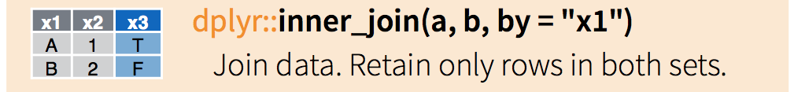

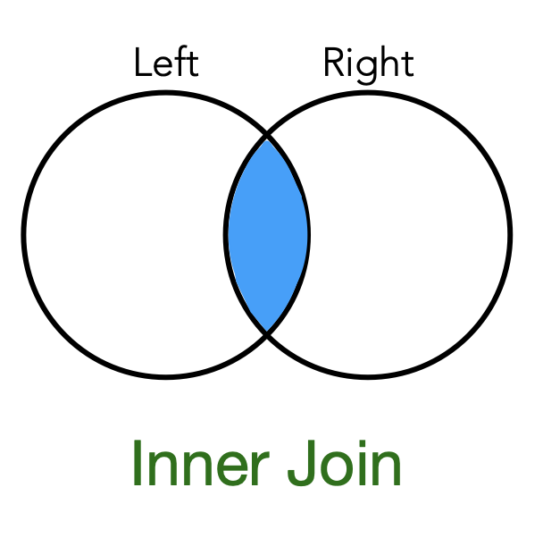

```r
left
```

| key1 | A | B |
| --- | --- | --- |
| K0 | A0 | B0 |
| K1 | A1 | B1 |
| K2 | A2 | B2 |
| K3 | A3 | B3 |

```r
right
```

| key1 | C | D |
| --- | --- | --- |
| K0 | C0 | D0 |
| K1 | C1 | D1 |
| K1 | C2 | D2 |
| K4 | C3 | D3 |

```r
inner_join(left, right, by = "key1")
```

| key1 | A | B | C | D |
| --- | --- | --- | --- | --- |
| K0 | A0 | B0 | C0 | D0 |
| K1 | A1 | B1 | C1 | D1 |
| K1 | A1 | B1 | C2 | D2 |

### Full Join

A full join returns all rows from both datasets, filling in NA values for non-matching rows.

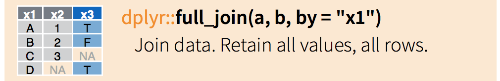

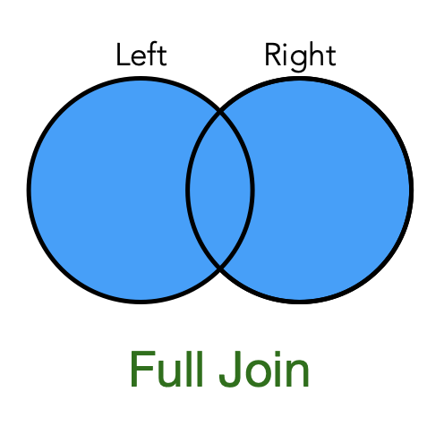

```r
left
```

| key1 | A | B |
| --- | --- | --- |
| K0 | A0 | B0 |
| K1 | A1 | B1 |
| K2 | A2 | B2 |
| K3 | A3 | B3 |

```r
right
```

| key1 | C | D |
| --- | --- | --- |
| K0 | C0 | D0 |
| K1 | C1 | D1 |
| K1 | C2 | D2 |
| K4 | C3 | D3 |

```r
full_join(left, right, by = "key1")
```

| key1 | A | B | C | D |
| --- | --- | --- | --- | --- |
| K0 | A0 | B0 | C0 | D0 |
| K1 | A1 | B1 | C1 | D1 |
| K1 | A1 | B1 | C2 | D2 |
| K2 | A2 | B2 | NA | NA |
| K3 | A3 | B3 | NA | NA |
| K4 | NA | NA | C3 | D3 |

## Binding multiple data frames

The `dplyr` package provides convenient functions forbinding data frames by row or column to combine one or more data frames into one data frame.

For illustration purposes, let’s use the following data frames in the subsequent examples.

```r
df1 = data.frame(
  ID         = 1:3,
  name       = c("Eva", "Charlie", "John"),
  occupation = c("Doctor", "Nurse", "Manager"))
df2 = data.frame(
  ID         = 4:6,
  name       = c("Peter", "Jane", "Alice"),
  occupation = c("Radiographer", "Therapist", "Consultant"))
df3 = data.frame(
  location   = c("Parkville", "Box Hill", "East Melbourne"),
  grade      = c("A", "A", "C"))
```

1. **Binding by Row:**
   - To bind data frames by row, you can use the `bind_rows()` function.
   - This function stacks data frames on top of each other, matching columns by name.

```r
df1
```

| ID | name | occupation |
| --- | --- | --- |
| 1 | Eva | Doctor |
| 2 | Charlie | Nurse |
| 3 | John | Manager |

```r
df2
```

| ID | name | occupation |
| --- | --- | --- |
| 4 | Peter | Radiographer |
| 5 | Jane | Therapist |
| 6 | Alice | Consultant |

```r
bind_rows(df1, df2)
```

| ID | name | occupation |
| --- | --- | --- |
| 1 | Eva | Doctor |
| 2 | Charlie | Nurse |
| 3 | John | Manager |
| 4 | Peter | Radiographer |
| 5 | Jane | Therapist |
| 6 | Alice | Consultant |

2. **Binding by Column:**
   - To bind data frames by column, you can use the `bind_cols()` function from `dplyr`.
   - This function appends columns from one data frame to another, matching rows by position.

```r
df1
```

| ID | name | occupation |
| --- | --- | --- |
| 1 | Eva | Doctor |
| 2 | Charlie | Nurse |
| 3 | John | Manager |

```r
df3
```

| location | grade |
| --- | --- |
| Parkville | A |
| Box Hill | A |
| East Melbourne | C |

```r
bind_cols(df1, df3)
```

| ID | name | occupation | location | grade |
| --- | --- | --- | --- | --- |
| 1 | Eva | Doctor | Parkville | A |
| 2 | Charlie | Nurse | Box Hill | A |
| 3 | John | Manager | East Melbourne | C |

That wraps up our exploration of data transformation using the `dplyr` package. In the next section, we’ll delve into visualization with the `ggplot2` package from the tidyverse suite. We’ll apply the functions we’ve learned in this section to generate various plots. Stay tuned for more!